# Untitled

2022-07-18

## Introduction

Data can be accessed from [WFP](https://data.humdata.org/dataset/wfp-food-prices-for-myanmar?force_layout=desktop) and [Mercy Corps’ Market Analysis Unit (MAU)](http://themimu.info/market-analysis-unit).

### Food prices vs. inflation

Inflation in food commodities has largely outstripped the overall pace of inflation in Myanmar as a whole. In the plot below, commodities which have been sufficiently measured (more than 1,000 observations between 2020 and the present), the bars are coloured on the number of observations where prices have increased more than 1% a month – for reference, this is roughly equivalent to the official inflation rate of 12.63% (Central Statistics Organisation) for the whole of 2021.

Price increases are particularly predominant in palm oil. Tomatoes were the only commodity to have not experienced overall price increases beyond Myanmar’s inflation rate; however, as will be examined, its prices have undergone significant volatility.

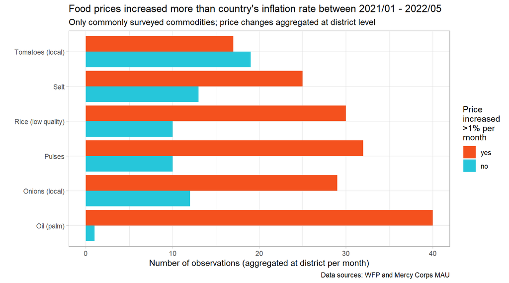

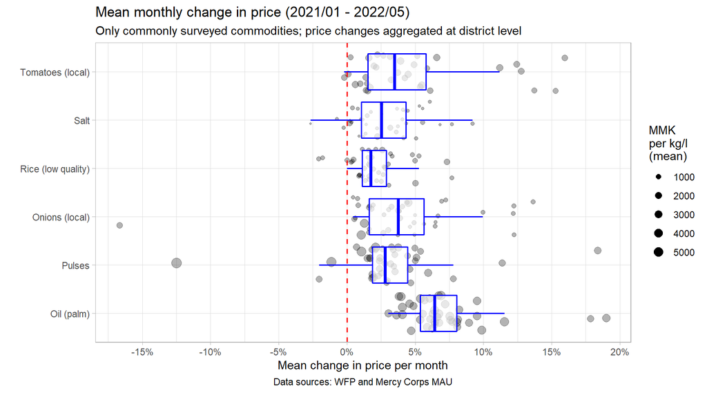

Average month-on-month increase in prices 2021/01 - 2022/05

| commodity | %month_on_month_change |
| --- | --- |
| Oil (palm) | 6.5% |
| Onions (local) | 1.7% |
| Pulses | 1.9% |
| Rice (low quality) | 1.85% |
| Salt | 1.63% |
| Tomatoes (local) | 1.16% |

Data sources: WFP and Mercy Corps MAU

### Food prices over time

Once aggregated at state level, Shan East is visibly an area of concern, having experienced the largest or near-the-largest price increases in salt, rice, tomatoes, pulses and onions. Whilst price shocks are prevalent across the entire country, the situation does not appear to be as severe in Bago.

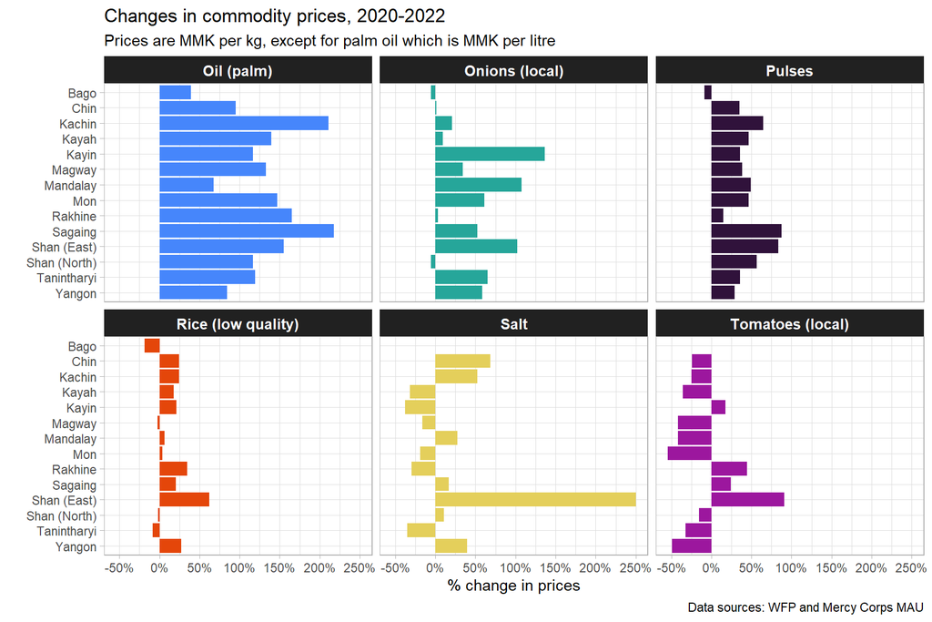

[output not shown]

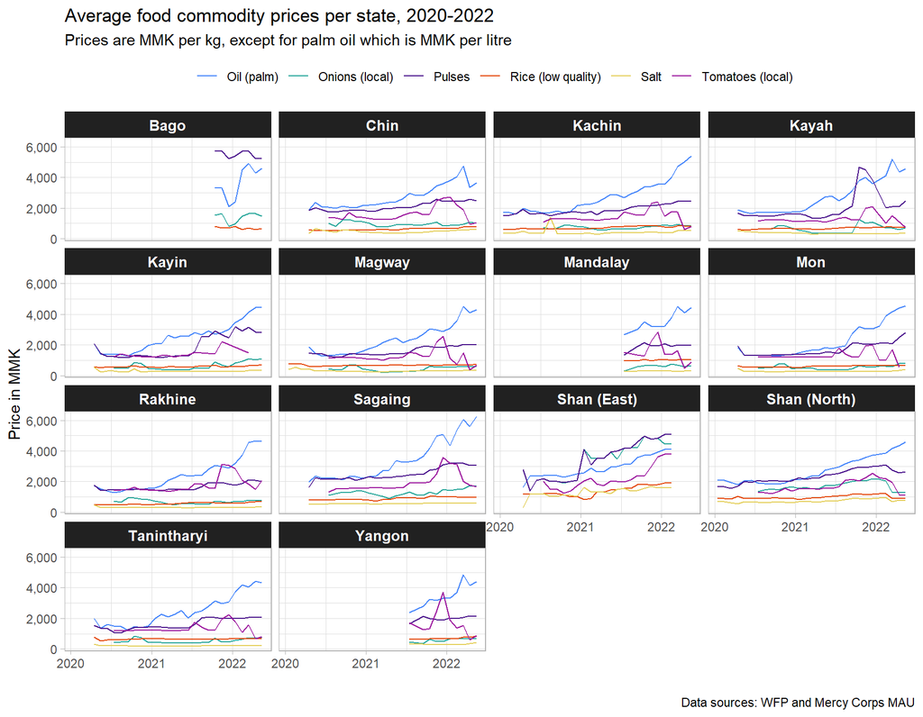

Palm oil is most expensive in Sagaing, though all areas have experienced significant price increases. Shan East and Kayah are notable for their large and constant price shocks, with food prices spiking repeatedly. It is also apparent that palm oil, pulses and tomatoes have all experienced significant price volatility, which will be discussed in the next section.

### Price shocks and volatility

Price volatility, represented below by the standard deviation in prices, has been most pronounced amongst palm oil, pulses and tomatoes, with tomatoes displaying extreme volatility in 2022.

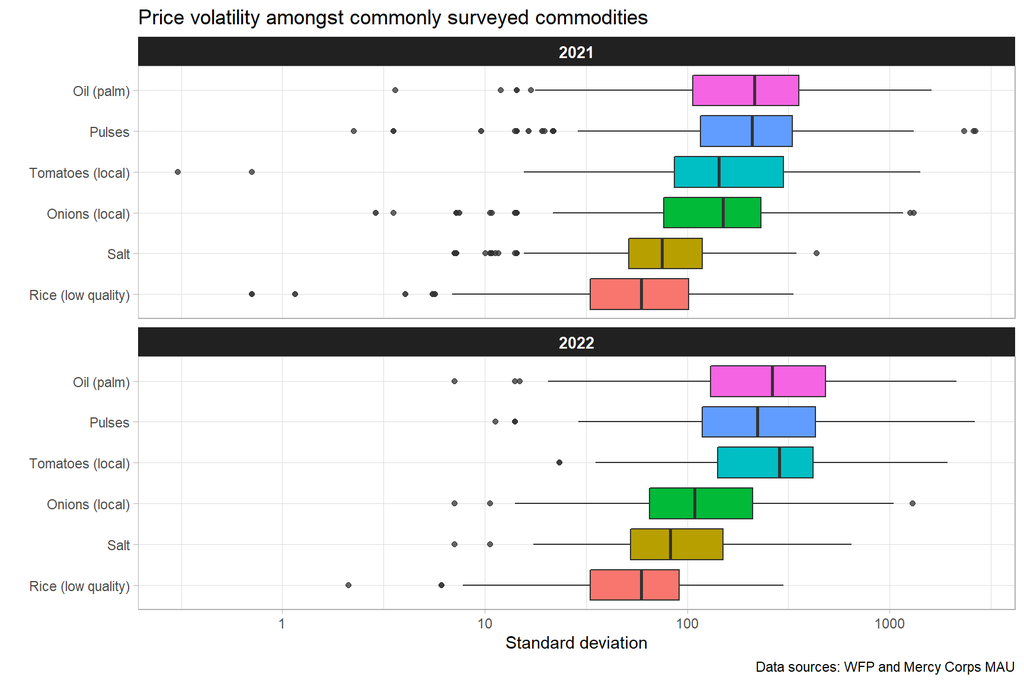

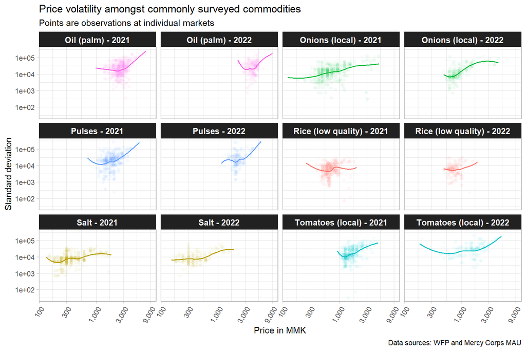